# 030102

## 演示：基本统计量

### 案例1：均值与百分位数

> - 均值(mean):各元素和除以元素个数
> - 中值(median):先将数组升序排列;如果数组有奇数个元素,则直接取回中间元素;如果是偶 数个,则取中间两个元素的平均值(因此,该中值可能并不是数组中的元素)
> - 百分位数(quantile):指定一个百分比x%,将数组升序排列后,跳过数组中前x%个元素,返 回随后的那个元素。返回的元素值将大于数组中指定百分比的元素。median可以视为 quantile(array, 0.5),也就是取50%百分位数

下面的代码定义了一个计算百分位数的函数：

```python
import numpy as np
import collections

arr = np.arange(1, 11, 1)
print("数组：", arr)

m1 = np.mean(arr)            # 均值
print("均值：", m1)

m2 = np.median(arr)          # 中位数/中值
print("中位数：", m2)

def quantile(array, percentage):
    """百分位数"""
    index = (int)(percentage * len(array))
    return sorted(array)[index]

m3 = quantile(arr, 0.3)      # 30%百分位数
print("30%分位数：", m3)
```

```
数组： [ 1  2  3  4  5  6  7  8  9 10]
均值： 5.5
中位数： 5.5
30%分位数： 4
```

### 案例2：偏差相关的计算

> - 偏差(deviation):数组中每个元素与数组平均值的差,返回一个数组，可记作： $ dev(x) = x_i - \bar{x}, i=1,2,,\cdots,n $
> - 方差(variance):每个元素的偏差平方和,再除以有效元素总数，可记作： $ var(x) = \dfrac{\sum_{i=1}^{n} (x^{(i)} - \bar{x})^2}{n} $
>   - 无偏估计方差(unbiased estimator):有效元素总数为n − 1
>   - 有偏估计方差(biased estimator):有效元素总数为n
>   - 方差指示了一个数组中各个元素的离散程度
> - 标准差(standard variance):又叫均方差,方差的平方根。也分为有偏估计和无偏估计标准差。可记作： $ std(x)=\sqrt{var(x)} $
> - 协方差(covariance):对于长度相同的两个数组,先求出各自的偏差,然后求出两组偏差的对 应元素乘积之和,最后除以有效元素总数。可记作： $ cov(x, y)=\dfrac{\sum_i^n (\bar{x}-x^{(i)})(\bar{y}-y^{(i)})}{n} $ 其中：
>   - $ \bar{y} $：数组y的平均值
>   - $ \bar{x} $：数组x的平均值
>   - $ x^{(i)} $：数组x中的第i个元素
>   - $ y^{(i)} $：数组y中的第i个元素
> - 相关性(correlation):对于两个数组(元素个数相同),计算出协方差以及两个标准差,然后用协方差除以标准差乘积。可记作：$ cor(x, y) = \dfrac{cov(x, y)}{std(x)*std(y)} $

下面的代码采用多种方式计算偏差相关的统计量：

```python
arr = np.arange(1, 6, 1)
print("=============偏差与方差计算==============")
print("数组1：", arr)

def deviation(array):
    """偏差"""
    avg = np.mean(array)
    return [el - avg for el in array]

print("偏差：", deviation(arr))        # 偏差:[-2,-1,0,1,2]

def unbiased_variance(array):
    """无偏估计方差"""
    deviations = deviation(array)
    return sum([el**2 for el in deviations]) / (len(array) - 1)

def biased_variance(array):
    """有偏估计方差"""
    deviations = deviation(array)
    return sum([el**2 for el in deviations]) / len(array)

print("无偏方差：", unbiased_variance(arr))  # 2.5
print("无偏方差(numpy)：", np.var(arr, ddof=1))     # ddof=1表示计算无偏方差
print("有偏方差：", biased_variance(arr))    # 2.0
print("有偏方差(numpy)：", np.var(arr, ddof=0))     # ddof=0表示计算有偏方差
print("无偏标准差(numpy)：", np.std(arr, ddof=1))     # 无偏标准差:1.581
print("有偏标准差(numpy)：", np.std(arr, ddof=0))     # 有偏标准差:1.414

def unbiased_covariance(arrayX, arrayY):
    """无偏协方差"""
    deX = deviation(arrayX)
    deY = deviation(arrayY)
    return sum([el1 * el2 for el1, el2 in zip(deX, deY)]) / (len(arrayX) - 1)

def unbiased_correlation(arrayX, arrayY):
    """无偏相关性"""
    deX = np.std(arrayX, ddof=1)
    deY = np.std(arrayY, ddof=1)
    if(deX > 0 and deY > 0):
        return unbiased_covariance(arrayX, arrayY) / (deX * deY)
    else:
        return 0

print("=============协方差计算==============")
arr2 = [2,4,6,8,10]
arr3 = [-2,-4,-6,-8,-10]
arr4 = [6, -100, 3, 20, -90]
print("数组1与数组1自身协方差：",unbiased_covariance(arr, arr))   # 2.5
print("数组2：", arr2)
print("数组1与数组2协方差：",unbiased_covariance(arr, arr2))  # 5.0
print("数组2与数组2自身协方差：",unbiased_covariance(arr2, arr2)) # 10.0
print("数组1与数组2协方差矩阵(numpy):")
# 无偏协方差,返回一个矩阵,矩阵中第[i,j]个元素代表第i个数组和第j个数组之间的协方差
print(np.cov(arr, arr2, ddof=1))

print("=============相关性计算==============")
print("数组3：", arr3)
print("数组4：", arr4)
print("数组1与数组2相关性：", unbiased_correlation(arr, arr2)) # 1.0,表示最强正相关
print("数组1与数组3相关性：", unbiased_correlation(arr, arr3)) # -1.0,表示最强负相关
print("数组1与数组4相关性：", unbiased_correlation(arr, arr4)) # -0.19,表示相关性很小

# 构造4行元素的矩阵
# 无偏相关性,返回一个矩阵,矩阵中第[i,j]个元素代表第i行和第j行之间的相关性
A = np.array([arr, arr2, arr3, arr4])
print("数组1,2,3,4相互之间的相关性矩阵(numpy)：")
print(np.corrcoef(A))
```

```
=============偏差与方差计算==============
数组1： [1 2 3 4 5]
偏差： [-2.0, -1.0, 0.0, 1.0, 2.0]
无偏方差： 2.5
无偏方差(numpy)： 2.5
有偏方差： 2.0
有偏方差(numpy)： 2.0
无偏标准差(numpy)： 1.5811388300841898
有偏标准差(numpy)： 1.4142135623730951
=============协方差计算==============
数组1与数组1自身协方差： 2.5
数组2： [2, 4, 6, 8, 10]
数组1与数组2协方差： 5.0
数组2与数组2自身协方差： 10.0
数组1与数组2协方差矩阵(numpy):
[[ 2.5  5. ]
 [ 5.  10. ]]
=============相关性计算==============
数组3： [-2, -4, -6, -8, -10]
数组4： [6, -100, 3, 20, -90]
数组1与数组2相关性： 0.9999999999999998
数组1与数组3相关性： -0.9999999999999998
数组1与数组4相关性： -0.196977338422431
数组1,2,3,4相互之间的相关性矩阵(numpy)：
[[ 1.          1.         -1.         -0.19697734]
 [ 1.          1.         -1.         -0.19697734]
 [-1.         -1.          1.          0.19697734]
 [-0.19697734 -0.19697734  0.19697734  1.        ]]
```

### 案例3：查看正态分布的概率密度函数和累积分布函数

> - 概率密度函数：$ PDF(x)=\dfrac{1}{\sigma\sqrt{2\pi}} e^{-\frac{(x-\mu)^2}{2\sigma^2}} $
> - 累积分布函数：$ CDF(x)=\dfrac{1}{\sigma\sqrt{2\pi}} \int_{-\infty}^{x} e^{-\frac{(x-\mu)^2}{2\sigma^2}}dx $

下面的代码绘制了在不同的$ \sigma $ 和 $ \mu $组合下PDF和CDF曲线：

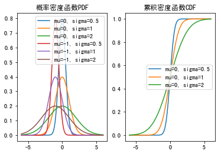

```python
import numpy as np
from scipy.integrate import quad
import matplotlib as mpl
import matplotlib.pyplot as plt
%matplotlib inline

# 定义概率密度函数
def normal_pdf(x, mu, sigma):
    return 1 / (sigma * np.sqrt(2 * np.pi)) * np.exp(-(x - mu)**2 / (2*sigma**2))

# 定义累积分布函数(针对单个x变量积分计算)
def normal_integrate(x, mu, sigma):
    r, _ = quad(lambda t : np.exp(-(t - mu)**2 / (2*sigma**2)), -np.inf, x)
    return 1 / (sigma * np.sqrt(2 * np.pi)) * r

# 支持对数组形式的x分别计算累积分布
def normal_cdf(x, mu, sigma):
    return [normal_integrate(i, mu, sigma) for i in x]

mpl.rcParams['font.sans-serif']=['SimHei']  #用来正常显示中文标签
mpl.rcParams['axes.unicode_minus']=False    #用来正常显示负号

x = np.linspace(-6, 6, 100)

# 绘制PDF的比较图
handles = []
labels = []
plt.subplot(1,2,1)
for mu in [0, -1]:
    for sigma in [0.5, 1, 2]:
        y1 = normal_pdf(x, mu, sigma)
        f, = plt.plot(x, y1)
        handles.append(f)
        labels.append("mu={0}, sigma={1}".format(mu, sigma))
plt.title(u"概率密度函数PDF")
plt.legend(handles=handles, labels=labels)

# 绘制CDF的比较图
handles.clear()
labels.clear()
plt.subplot(1,2,2)
for mu in [0]:
    for sigma in [0.5, 1, 2]:
        y1 = normal_cdf(x, mu, sigma)
        f, = plt.plot(x, y1)
        handles.append(f)
        labels.append("mu={0}, sigma={1}".format(mu, sigma))
plt.legend(handles=handles, labels=labels)
plt.title(u"累积密度函数CDF")

plt.show()
```

### 案例4：观察随机数的分布情况

> - np.random.rand、fandom、randint方法均可以生成均匀分布的随机数
> - np.randn方法生成的是按照正态分布的随机数

下面的代码演示了如何生成海量的随机数来观察这些随机数是否遵循均匀分布(可以看到0～100出现的次数都在1000左右波动)：

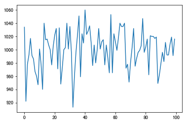

```python
import collections as col

total_count = 100000
section_count = 100
min_value = 0
max_value = 100
# 0~100之间的整数,随机生成100000个
data = np.random.randint(min_value, max_value, total_count)
counts = col.Counter(data)    # 统计每个整数出现的次数
x = np.arange(section_count)
y = np.zeros(section_count)

for i in x:
    y[i] = counts[i]

plt.plot(x, y)
plt.show()
```

下面的代码演示了如何生成海量的随机数来观察这些随机数是否遵循正态分布：

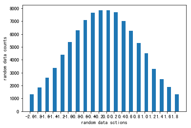

```python
total_count = 100000
section_count = 20
section_max_value = 2.0 #仅统计-2.0~2.0之间的样本数
section_min_value = -2.0
section_interval = (section_max_value - section_min_value) / section_count
data = np.random.randn(total_count)
counts = np.array(section_count)
x = np.arange(section_min_value, section_max_value, section_interval)
y = np.zeros(len(x))
# 按照-2.0~-1.9, -1.9~-1.8...... -0.1~0.0, 0.0~0.1, 0.1~0.2....1.9~2.0的区间计算data在各区间的数量
for value in data:
    if value > section_max_value or value < section_min_value:
        continue
    # 计算区间编号。只取计算结果的整数部分作为编号
    index = int((value - section_min_value) / section_interval)
    y[index] += 1

plt.xticks(np.arange(section_min_value, section_max_value, section_interval))
bar_width = section_interval/2
plt.bar(x+bar_width/2, y, bar_width)
plt.xlabel("random data sctions")
plt.ylabel("random data counts")
plt.show()
```